# R 實作：三種 t 檢定

Week 09｜Part 2・R 實作：pt()、qt() 與 t.test()

HT3001B 生物統計學與 R

2026-11-05

## 今天要在 R 完成哪三個檢定？

| 案例 | 資料結構 | R 的寫法 |
| --- | --- | --- |
| 大鼠迷宮 | 一組 25 隻，和基準 60 比 | `t.test(x, mu = 60)` |
| 網路搜尋 | 兩組不同的人 | `t.test(y ~ group, var.equal = TRUE)` |
| 影片前後測 | 同一人量兩次 | `t.test(pre, post, paired = TRUE)` |

大鼠與網路搜尋只有摘要統計量，先把公式寫成 R 程式；再用示範資料練習 `t.test()`。影片案例有 20 人的完整資料。

本週 R 實作；[R stats::t.test 官方說明](https://stat.ethz.ch/R-manual/R-devel/library/stats/html/t.test.html)。案例同 Week 09 t 檢定投影片。

## 把檔案放在同一個 Project

下載學生起始 QMD · 完整 R 程式 · 影片資料 CSV

- 三個檔案與 `.Rproj` 放在同一層，`read.csv("week09_part2_film_attitude.csv")` 才讀得到。
- 另存起始檔為 `week09_part2_r_t_tests_lab.qmd`，在自己的檔案上作答。
- 本週只用 R 內建的 `stats` 函數，不必安裝套件。

本週 R 實作；week09_part2_r_t_tests.R。

## pt() 與 qt()：從 t 求面積，從面積求 t

```r
qt(0.975, df = 24)
```

```
#> [1] 2.063899
```

```r
2 * pt(-abs(2.57), df = 24)
```

```
#> [1] 0.01680383
```

`pt()` 回傳左尾面積。雙尾 $p$ 值取 $-|t|$ 的左尾，再乘 2。`qt()` 反過來，輸入左尾面積，得到臨界值。

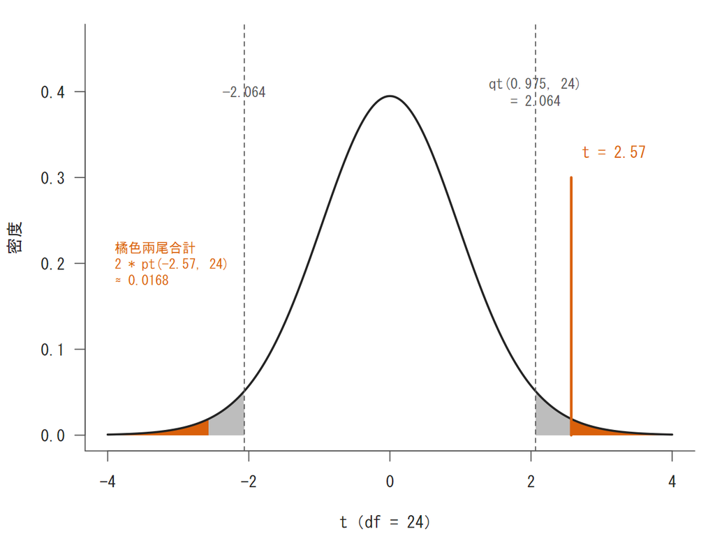

灰色虛線標出 α = .05 的拒絕域界線，橘色兩尾合計是 p 值。

[R stats::TDist 官方說明](https://stat.ethz.ch/R-manual/R-devel/library/stats/html/TDist.html)。自製圖，數值取自大鼠迷宮案例。

## 大鼠迷宮｜把公式寫成程式

```r
n <- 25; xbar <- 66; mu0 <- 60; SS <- 3259
s2 <- SS / (n - 1)                  # 樣本變異數
se <- sqrt(s2 / n)                  # 估計標準誤
t_rat <- (xbar - mu0) / se
p_rat <- 2 * pt(-abs(t_rat), df = n - 1)
c(t = t_rat, p = p_rat)
```

```
#>          t          p
#> 2.57445139 0.01663628
```

每個物件對應 t 檢定投影片的一行公式。用未四捨五入的 $t$ 計算，$p\approx .0166$。

本週 R 實作；week09_part2_r_t_tests.R 第 A 段。公式見 IMS 2e §19.2.5。

## 示範資料：只對齊摘要統計量

```r
make_demo <- function(n, mean, sd) {
  z <- rnorm(n)
  z <- (z - mean(z)) / sd(z)   # 平均 0、標準差 1
  mean + sd * z
}
set.seed(1105)
rat <- make_demo(25, mean = 66, sd = sqrt(3259 / 24))
c(mean = mean(rat), SS = sum((rat - mean(rat))^2))
```

```
#> mean   SS
#>   66 3259
```

`rat` 的平均與 $SS$ 和課堂案例相同，但它是**示範資料**，不是原實驗的逐隻紀錄，也不是整數次數。

本週 R 實作；week09_part2_r_t_tests.R。示範資料由程式產生。

## 有逐筆資料時，t.test() 一行完成

```r
fit_rat <- t.test(rat, mu = 60)
fit_rat
fit_rat$statistic   # t
fit_rat$parameter   # df
fit_rat$p.value
fit_rat$conf.int
```

`mu` 設定虛無假設的母體平均。沒寫 `mu` 時，預設是 0。

```
    One Sample t-test

data:  rat
t = 2.5745, df = 24, p-value = 0.01664
alternative hypothesis: true mean
  is not equal to 60
95 percent confidence interval:
 61.18989 70.81011
sample estimates:
mean of x
       66
```

本週 R 實作；[R stats::t.test 官方說明](https://stat.ethz.ch/R-manual/R-devel/library/stats/html/t.test.html)。

## 讀 t.test() 輸出的每一列

| 輸出 | 意思 | 本例 |
| --- | --- | --- |
| `t` | 樣本平均與 60 相差幾個估計標準誤 | 2.5745 |
| `df` | 自由度 $n-1$ | 24 |
| `p-value` | 預設為雙尾 $p$ 值 | 0.01664 |
| `95 percent confidence interval` | 母體平均 $\mu$ 的 95% 信賴區間（confidence interval） | 61.19 至 70.81 |
| `mean of x` | 樣本平均 | 66 |

$p<.05$，與手算的決策相同。區間不含 60，兩者在雙尾 $\alpha=.05$ 下給出一致的判斷。

本週 R 實作；IMS 2e §19.2.5（單一樣本 t 的結果判讀）。

## 練習 1｜改成單尾，p 值會怎樣？

```r
t.test(rat, mu = 60, alternative = "greater")$p.value
```

執行前先預測：$p$ 值會變大、變小，還是不變？

約 0.0083，是雙尾 $p$ 值的一半，因為 $t$ 為正，只算右尾面積。`alternative` 可設 `"two.sided"`（預設）、`"greater"` 或 `"less"`。檢定方向要在看資料前決定；本例事先設定雙尾，結論仍依雙尾。

本週 R 實作；[R stats::t.test 官方說明](https://stat.ethz.ch/R-manual/R-devel/library/stats/html/t.test.html)。

## 網路搜尋｜把合併變異數寫成程式

```r
n1 <- 93;  m1 <- 3.78; v1 <- 1.42   # 網路搜尋組
n2 <- 102; m2 <- 3.07; v2 <- 1.25   # 非搜尋組
df_pool <- (n1 - 1) + (n2 - 1)
sp2 <- ((n1 - 1) * v1 + (n2 - 1) * v2) / df_pool
se_pool <- sqrt(sp2 * (1 / n1 + 1 / n2))
t_pool <- (m1 - m2) / se_pool
c(sp2 = sp2, se = se_pool, t = t_pool)
```

```
#>       sp2        se         t
#> 1.3310363 0.1654134 4.2922762
```

差的方向固定為搜尋組 − 非搜尋組，與 t 檢定投影片相同。

本週 R 實作；week09_part2_r_t_tests.R 第 B 段。公式見 Rosner 8e §8.4, pp. 286–289。

## 網路搜尋｜α = .001 的臨界值與 p 值

```r
qt(1 - 0.001 / 2, df = 193)
```

```
#> [1] 3.341649
```

```r
2 * pt(-abs(t_pool), df = 193)
```

```
#> [1] 2.796538e-05
```

雙尾 $\alpha=.001$，每尾 .0005，所以輸入 $1-.0005$。`2.796538e-05` 是科學記號，等於 0.00002797。

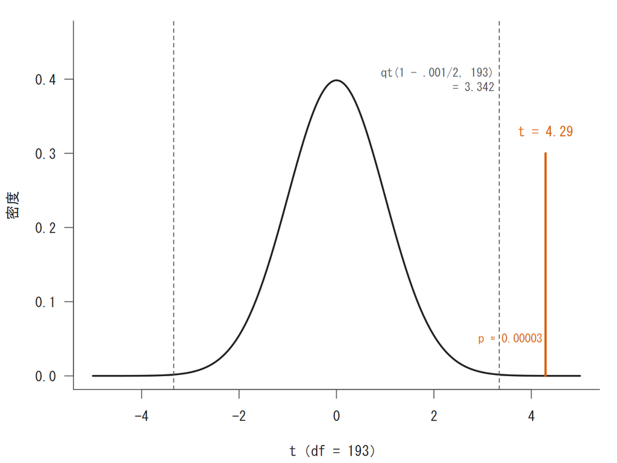

t = 4.29 落在 +3.342 的右側，p < .001。

[R stats::TDist 官方說明](https://stat.ethz.ch/R-manual/R-devel/library/stats/html/TDist.html)。自製圖，數值取自網路搜尋案例摘要。

## 獨立樣本用長格式，配對用寬格式

- 長格式（long format）：每列一人，一欄組別、一欄分數。公式 `y ~ group` 讀作「依 `group` 分組比較 `y`」。
- 寬格式（wide format）：每列一人，前後測各占一欄，同一列相減得到差值。

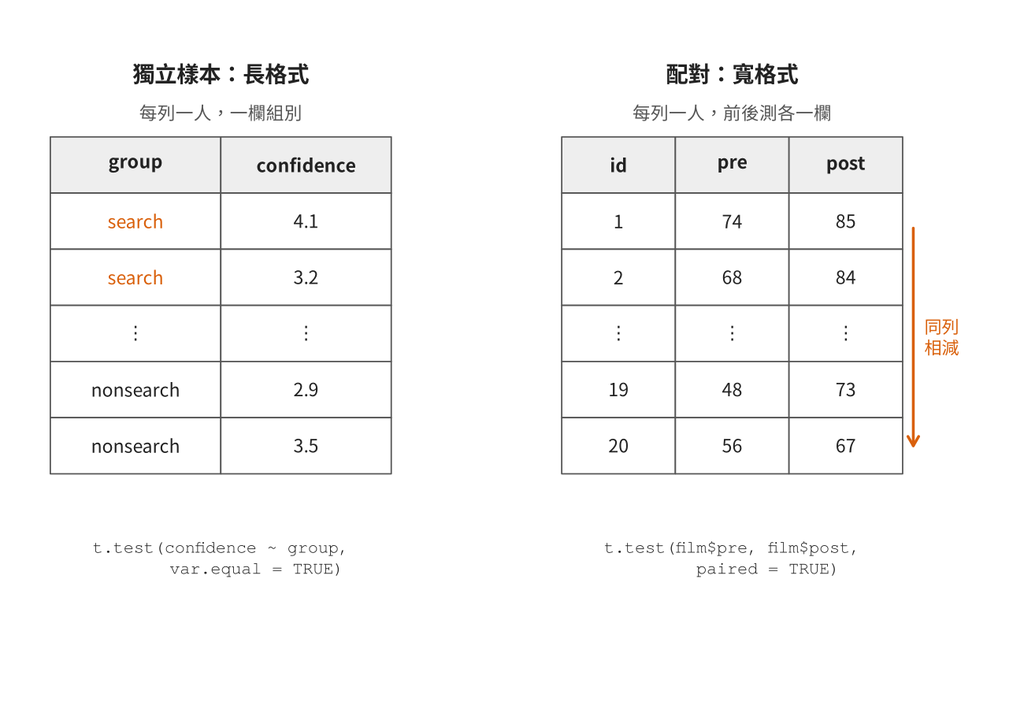

左表的分數為示意；右表取自影片資料。

本週 R 實作；[IMS 2e §21.1（辨認配對資料）](https://openintro-ims.netlify.app/inference-paired-means)。自製示意圖。

## 建立長格式的示範資料

```r
set.seed(2015)
search <- data.frame(
  group = rep(c("search", "nonsearch"), times = c(93, 102)),
  confidence = c(make_demo(93, 3.78, sqrt(1.42)),
                 make_demo(102, 3.07, sqrt(1.25))))
search$group <- factor(search$group,
                       levels = c("search", "nonsearch"))
tapply(search$confidence, search$group, mean)
```

```
#>    search nonsearch
#>      3.78      3.07
```

`rep(..., times = )` 產生 93 個 search 與 102 個 nonsearch。分數只對齊兩組的 $n$、平均與變異數，可能超出 1–7 分，不是原研究的作答。

本週 R 實作；week09_part2_r_t_tests.R。示範資料由程式產生。

## 合併法：加上 var.equal = TRUE

```r
fit_pool <- t.test(
  confidence ~ group,
  data = search,
  var.equal = TRUE,
  conf.level = 0.999)
fit_pool
```

`conf.level = 0.999` 與 $\alpha=.001$ 對應。區間不含 0，與 $p<.001$ 的決策一致。

```
    Two Sample t-test

data:  confidence by group
t = 4.2923, df = 193,
  p-value = 2.797e-05
99.9 percent confidence interval:
 0.1572465 1.2627535
sample estimates:
   mean in group search
                   3.78
mean in group nonsearch
                   3.07
```

本週 R 實作；Rosner 8e §8.4（等變異數雙樣本 t 檢定）。輸出已省略 alternative 一列並調整換行。

## 沒寫 var.equal 時，R 用 Welch 檢定

```r
fit_welch <- t.test(confidence ~ group, data = search)
```

| 方法 | 寫法 | $t$ | $df$ | $p$ |
| --- | --- | --- | --- | --- |
| 合併法 | `var.equal = TRUE` | 4.292 | 193 | 2.80e-05 |
| Welch t 檢定（Welch’s t test） | 預設 | 4.280 | 188.4 | 2.98e-05 |

Welch 檢定不假定兩組母體變異數相等，自由度由兩組變異數與樣本數算出。本例兩組變異數接近，兩種結果相近。報告時要寫明採用哪一種。

本週 R 實作；[R stats::t.test 官方說明](https://stat.ethz.ch/R-manual/R-devel/library/stats/html/t.test.html)；[IMS 2e §20.3（獨立兩組平均差）](https://openintro-ims.netlify.app/inference-two-means)。

## 因子層級決定相減方向

```r
levels(factor(c("search", "nonsearch")))
```

```
#> [1] "nonsearch" "search"
```

```r
search$group2 <- factor(search$group,
                        levels = c("nonsearch", "search"))
t.test(confidence ~ group2, data = search,
       var.equal = TRUE)$statistic
```

```
#>         t
#> -4.292276
```

- `t.test(y ~ group)` 計算**第一個層級減第二個層級**。
- 沒指定 `levels` 時，`factor()` 依字母排序，nonsearch 會排在前面。
- 先用 `levels()` 確認，再寫結論的方向。

本週 R 實作；week09_part2_r_t_tests.R。

## 效果量要自己算

```r
sp <- sqrt(sp2)
d  <- (m1 - m2) / sp
g  <- d * (1 - 3 / (4 * df_pool - 1))
c(sp = sp, d = d, g = g)
```

```
#>        sp         d         g
#> 1.1537055 0.6154084 0.6130138
```

`t.test()` 不輸出效果量。Cohen’s $d$ 以合併標準差為分母，約 .62；Hedges’ $g$ 乘上小樣本校正因子，本例樣本數大，兩者幾乎相同。

[Lakens, Ch. 6（§6.4–6.5，標準化平均差與偏差校正）](https://lakens.github.io/statistical_inferences/06-effectsize.html)。本週 R 實作。

## 影片｜讀入資料並算差值

```r
film <- read.csv("week09_part2_film_attitude.csv")
str(film)
```

```
#> 'data.frame':    20 obs. of  3 variables:
#>  $ id  : int  1 2 3 4 5 6 7 8 9 10 ...
#>  $ pre : int  74 68 41 54 50 90 79 98 37 44 ...
#>  $ post: int  85 84 42 56 66 99 103 98 34 37 ...
```

```r
film$D <- film$pre - film$post
c(sum(film$D), sum(film$D^2))
```

```
#> [1] -152 2956
```

```r
c(mean = mean(film$D), sd = sd(film$D))
```

```
#>      mean        sd
#> -7.600000  9.735448
```

總和與 t 檢定投影片附錄表相同。差值方向是前測 − 後測。

本週 R 實作；week09_part2_film_attitude.csv 由 t 檢定投影片附錄表逐列轉錄。影片案例資料標示為 Devoe (1990)。

## 影片｜先看每個人的變化

```r
plot(c(1, 2),
     range(film[c("pre", "post")]),
     type = "n", xaxt = "n",
     xlab = "", ylab = "態度分數")
axis(1, at = c(1, 2),
     labels = c("前測", "後測"))
segments(1, film$pre,
         2, film$post)
```

`segments()` 把同一列的前測與後測連成一條線。

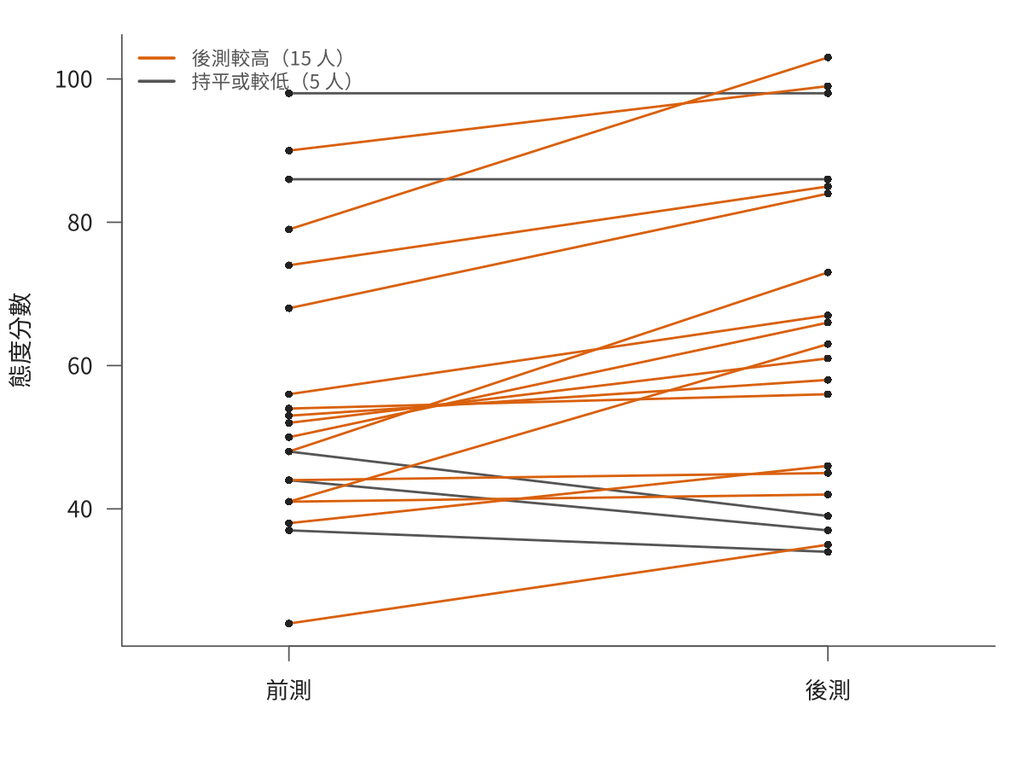

每條線是一個人；15 人後測較高。

本週 R 實作；自製圖，資料為 week09_part2_film_attitude.csv。

## paired = TRUE 等於對差值做單一樣本 t

```r
fit_paired <- t.test(film$pre, film$post,
                     paired = TRUE)
fit_paired
fit_diff <- t.test(film$D, mu = 0)
c(fit_paired$statistic,
  fit_diff$statistic)
```

```
#>         t         t
#> -3.491183 -3.491183
```

$t=-3.49$，$df=19$，$p=.002444$；95% CI 為 −12.16 至 −3.04。差的方向是第一個向量減第二個向量。

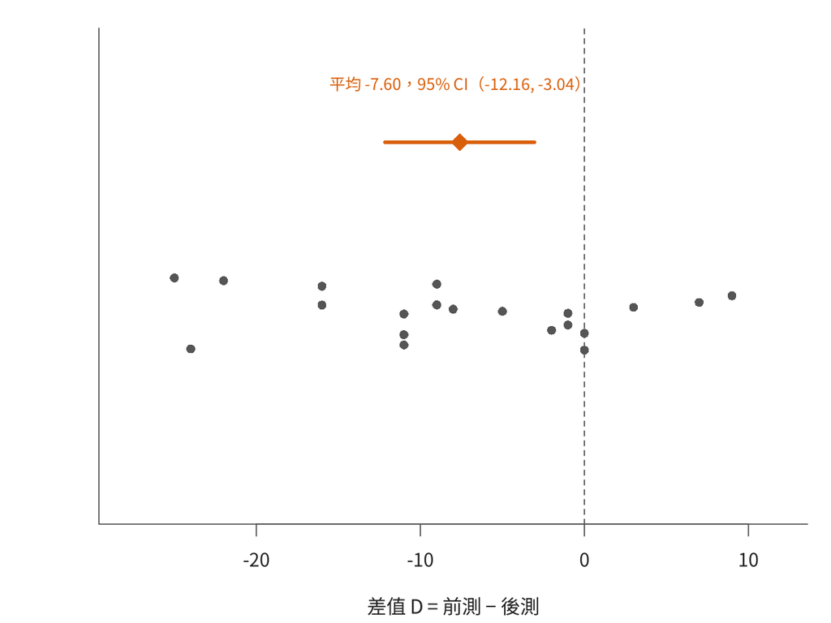

20 個差值的平均為 −7.60，95% CI 不含 0。

本週 R 實作；[IMS 2e §21.3.3（配對 t）](https://openintro-ims.netlify.app/inference-paired-means)。

## 練習 2｜忘記 paired = TRUE

```r
t.test(film$pre, film$post)
```

執行前先預測：$df$ 和 $p$ 值會怎麼變？

R 把兩欄當成兩組不同的人，做 Welch 檢定：$df\approx37.4$，$p\approx.265$。平均差仍是 −7.6，但標準誤包含了人與人之間的分數差異，區間變寬。要不要配對由資料怎麼收集決定，不看哪個 $p$ 值較小。

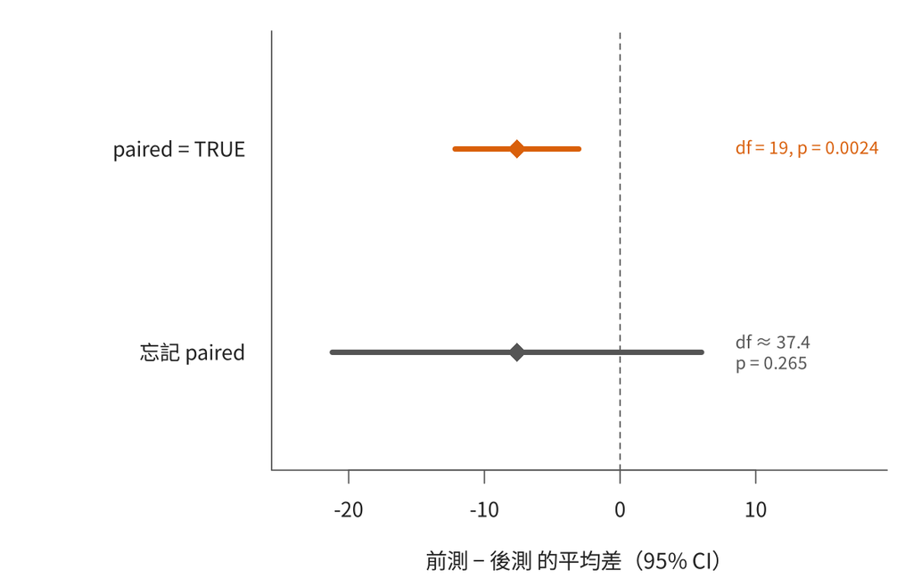

同樣的平均差，忘記配對時區間跨過 0。

本週 R 實作；[IMS 2e §21.3（配對資料）](https://openintro-ims.netlify.app/inference-paired-means)。

## 配對資料的效果量 d_z

```r
d_z <- mean(film$D) / sd(film$D)
d_z
```

```
#> [1] -0.7806523
```

分母是**差值的標準差** $s_D$，不是合併標準差。負號對應「前測 − 後測」，代表後測較高；只報大小時寫 $|d_z|\approx.78$。

[Lakens, Ch. 6（配對效果量 d_z）](https://lakens.github.io/statistical_inferences/06-effectsize.html)。本週 R 實作。

## 整合｜三種 t 檢定的 R 寫法

| 設計 | 資料格式 | 呼叫 | $df$ |
| --- | --- | --- | --- |
| 單一樣本 | 一個向量 | `t.test(x, mu = mu0)` | $n-1$ |
| 獨立樣本（合併法） | 長格式 | `t.test(y ~ g, data = d, var.equal = TRUE)` | $n_1+n_2-2$ |
| 獨立樣本（Welch，預設） | 長格式 | `t.test(y ~ g, data = d)` | 由軟體計算 |
| 配對 | 寬格式兩欄 | `t.test(pre, post, paired = TRUE)` | 配對數 $-1$ |

報告前確認三件事：相減方向、`conf.level` 與 $\alpha$ 是否對應、效果量的分母。

本週 R 實作；[IMS 2e Ch. 19–21（平均數推論）](https://openintro-ims.netlify.app/statistical-inference)。

## 附錄｜檢定力的常態近似

```r
crit_diff <- qt(1 - 0.001 / 2, df = 193) * se_pool
power <- pnorm(crit_diff, mean = 0.71, sd = se_pool,
               lower.tail = FALSE) +
         pnorm(-crit_diff, mean = 0.71, sd = se_pool)
c(crit_diff = crit_diff, power = power)
```

```
#> crit_diff     power
#> 0.5527535 0.8291032
```

以常態近似估計檢定力：以 t 臨界值乘上固定標準誤得到平均差刻度上的界線，再用常態曲線近似兩側拒絕域的面積。

[IMS 2e §14.4（檢定力）](https://openintro-ims.netlify.app/foundations-errors)；Rosner 8e §8.9, pp. 307–311。本週 R 實作。

## Slido｜R 程式題

三題單選，每題 45 秒。題目在 Slido 上作答，由課堂啟動。

[**開啟 Slido 作答頁**](https://app.sli.do/event/1jvhioqZKKM7xUwqNzn4av) · 活動代碼 **2249905**

[figure not shown]

第九週 Slido 作答入口 QR code，活動代碼 2249905。

[第九週 Slido](https://app.sli.do/event/1jvhioqZKKM7xUwqNzn4av)；本週已教 R 語法：t.test()、factor()。